# FrontRange HEAT: Incident Data Analysis

Prepared by Will Hanrott from data generated on 7th July 2015.

Data includes all Incidents created in FrontRange HEAT between 17th April 2015 and 6th July 2015 (inclusive)

## Which Symptoms Are Being Reported?

The data has been filtered:

- to remove Symptom = Spam
- to remove data for weekends

The data has been grouped by day and by Symptom.

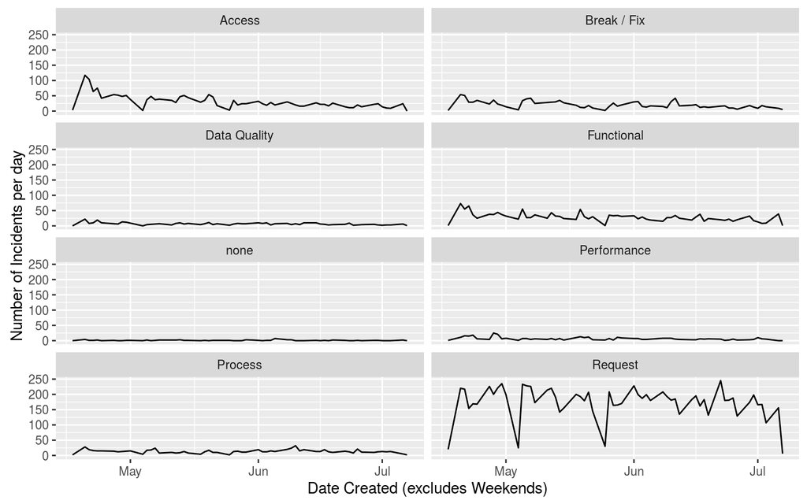

## Which Teams are Logging Incidents?

The data has been filtered:

- to remove Symptom = Spam
- to remove data for weekends
- to include Teams which have logged greater than 100 incidents

Please note that the scales on the ‘y’ axis are different to the panels above. The ‘x’ axis scales are the same.

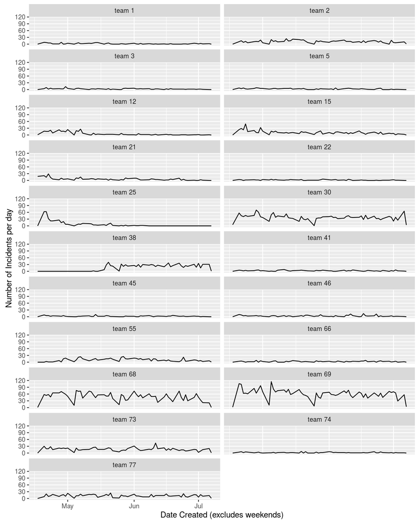

## Who are the top incident Owners and what are the Symptoms?

The data has been filtered:

- to remove Symptom = Spam
- to remove data for weekends
- to include Owners who have logged at least 200 incidents

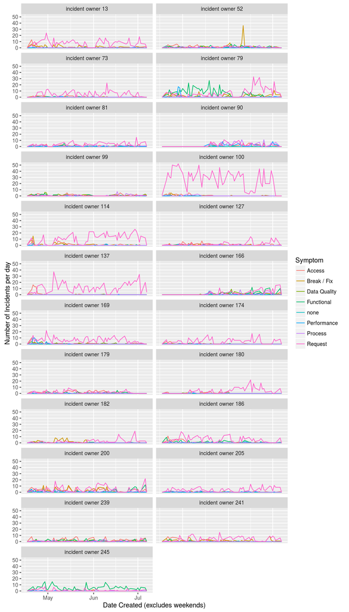

## Which Symptoms and Causes are most strongly correlated?

The data has been filtered:

- to remove Symptom = Spam
- to remove data for weekends

NB: The size is the log2 of the total number of incidents for each point.

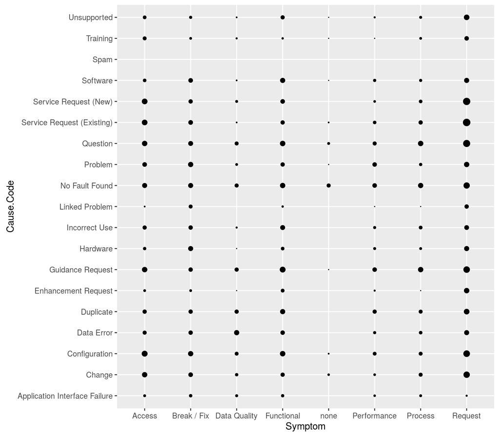

## Which are the Customers with the highest number of incidents?

The data has been filtered:

- to remove Symptom = Spam
- to remove data for weekends

| Customer Name | Customer Email | Frequency |
| --- | --- | --- |
| customer 53 | person@provider.com | 30 |
| customer 303 | person@provider.com | 32 |
| customer 1011 | person@provider.com | 31 |
| customer 1023 | person@provider.com | 33 |
| customer 1798 | person@provider.com | 2932 |
| customer 1859 | person@provider.com | 32 |
| customer 1915 | person@provider.com | 30 |
| customer 1998 | person@provider.com | 29 |
| customer 2264 | person@provider.com | 33 |
| customer 2600 | person@provider.com | 35 |
| customer 2631 | person@provider.com | 34 |
| customer 2966 | person@provider.com | 29 |
| customer 2973 | person@provider.com | 32 |
| customer 3092 | person@provider.com | 52 |
| customer 3153 | person@provider.com | 32 |
| customer 3660 | person@provider.com | 36 |
| customer 3777 | person@provider.com | 59 |
| customer 4018 | person@provider.com | 36 |
| customer 4549 | person@provider.com | 145 |
| customer 4588 | person@provider.com | 72 |